# Discrete Random Data

### Example 1

The number of cars arriving at a car wash per day is Poisson distributed with mean 20. Generate the numbers of cars arriving at this car wash daily, for 300 days. $Po(\lambda = 20)$

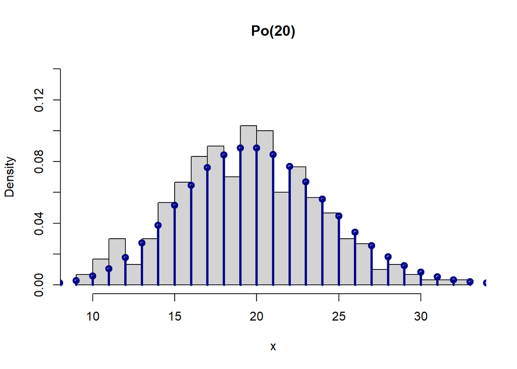

```r
> lambda <- 20
> x <- rpois(300, lambda)
> head(x, n = 15)
 [1] 21 18 22 24 16 23 13 12 16 22 17 17 20 29 20
> hist(x,
+      main = "Po(20)",
+      breaks = min(x):max(x),
+      probability = TRUE,
+      ylim = c(0, 0.14))
> points(0:100, dpois(0:100, lambda), type = "h", lwd = 3, col = "darkblue")
> points(0:100, dpois(0:100, lambda), type = "p", lwd = 3, col = "darkblue")
```

Generate how many cars are going to arrive weekly for 260 weeks?

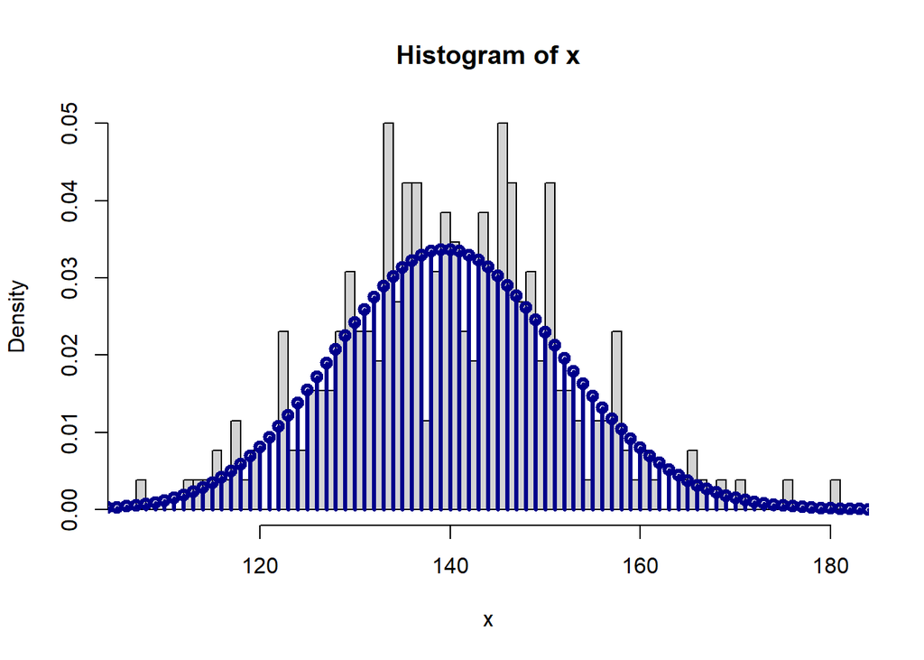

```r
> x <- rpois(260, 7*lambda)
> hist(x,
+      breaks = min(x):max(x),
+      probability = TRUE,
+      ylim = c(0, 0.05))
> points(0:200, dpois(0:200, 7*lambda), type = "h", lwd = 3, col = "darkblue")
> points(0:200, dpois(0:200, 7*lambda), type = "p", lwd = 3, col = "darkblue")
```

### Example 2

The average number of homes sold by the Home2U company is 20 homes per day. What is the probability that exactly 21 homes will be sold tomorrow?

Calculate it using probability mass function:
$$X \in Po(\lambda = 20)$$
$$P_X(21) = P(X = 21) = \frac{20^{21} e^{-20}}{21!} \approx 0.0846$$
Calculate it by using R:

```r
> lambda <- 20
> dpois(21, lambda)
[1] 0.08460506
```